# Progetto IDL

Lorenzo Meroni

3/9/2022

## Cariacamento dei dati

Carichiamo i dati appartenenti alle diverse classi della cartella intel, le immagini caricate ci serviranno per creare il training set e il test set.

```r
buildings <- list.files(path = "c:/data/intel/seg_train/buildings")
forest <- list.files(path = "c:/data/intel/seg_train/forest")
glacier <- list.files(path = "c:/data/intel/seg_train/glacier")
mountain <- list.files(path = "c:/data/intel/seg_train/mountain")
sea <- list.files(path = "c:/data/intel/seg_train/sea")
street <- list.files(path = "c:/data/intel/seg_train/street")

buildings_test <- list.files(path = "c:/data/intel/seg_test/buildings")
forest_test <- list.files(path = "c:/data/intel/seg_test/forest")
glacier_test <- list.files(path = "c:/data/intel/seg_test/glacier")
mountain_test <- list.files(path = "c:/data/intel/seg_test/mountain")
sea_test <- list.files(path = "c:/data/intel/seg_test/sea")
street_test <- list.files(path = "c:/data/intel/seg_test/street")
```

Vediamo ora il contenuto di un’immagine a titolo esemplificativo, nell’esempio qui sotto riportato stampiamo l’immagine di un palazzo appartenente al training set.

```r
img_path <- "c:/data/intel/seg_train/buildings/17903.jpg"
img <- image_load(img_path, target_size = c(150, 150))
img_tensor <- image_to_array(img)
img_tensor <- array_reshape(img_tensor, c(1, 150, 150, 3))
img_tensor <- img_tensor/255
dim(img_tensor)
```

```
## [1]   1 150 150   3
```

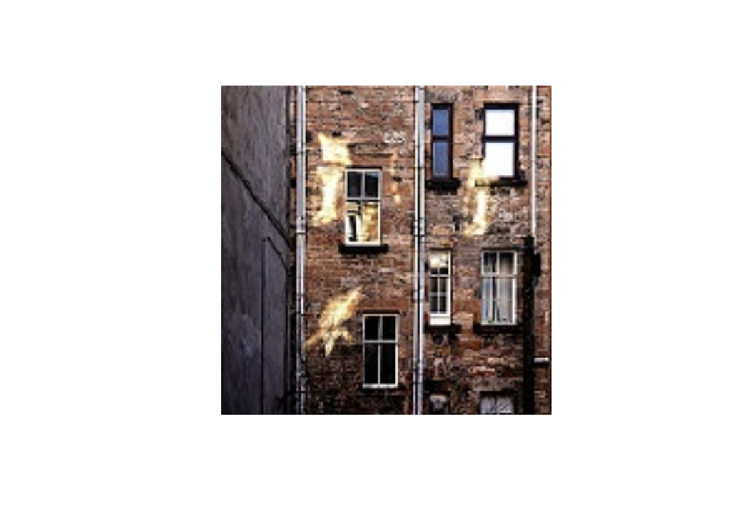

```r
plot(as.raster(img_tensor[1,,,]))
```

## Preparazione dei dati

Creiamo ora training set e validation set sulla base dei dati che abbiamo caricato precedentemente. Creeremo un training set formato da 12000 immagini e un validation set formato da 1146, il validation set serve per simulare il comportamento che avrebbe il modello sul test set. Creiamo inoltre il test set grazie alle immagini precedentemente salvate nella cartella di test.

```r
#Imposto un seme per ottenere sempre il medesimo risultato quando faccio sample
set.seed(123)
#Creo il train
train <- c(
  buildings[1:2000],
  forest[1:2000],
  glacier[1:2000],
  mountain[1:2000],
  sea[1:2000],
  street[1:2000]
)
train <- sample(train)
length(train)
```

```
## [1] 12000
```

```r
#creo il test
evaluation <- c(
  buildings[2001:2191],
  forest[2001:2191],
  glacier[2001:2191],
  mountain[2001:2191],
  sea[2001:2191],
  street[2001:2191]
)
evaluation <- sample(evaluation)
length(evaluation)
```

```
## [1] 1146
```

```r
test <- c(buildings_test, forest_test, glacier_test, mountain_test, sea_test, street_test)
test <- sample(test)
```

## Funzioni per creare le etichette per l’apprendimento

Con queste due funzioni traformiamo le immagini in array di dimensione (1,150,150,3) e creiamo le etichette in maniera tale per cui il nostro apprendimento funzioni e la validazione abbia un controllo.

```r
#La dimensione è 150*150*3
data_prep <- function(immagini, indirizzo, lista_immagini){

  n_elementi <- length(immagini)
  #inizializiamo l'oggetto dove salvare l'output (array)
  reference_array <- array(NA, dim=c(n_elementi,150, 150, 3))

  for (i in seq(length(immagini))) {
    #lista delle possibili categorie
    folder_list <- list("buildings", "forest", "glacier", "mountain", "sea", "street")
    for(j in 1:length(folder_list)) {
      if(immagini[i] %in% lista_immagini[[j]]) {
        #se l'immagine (formato jpg) apparteniene a una categoria allora crea
        #determinato percorso
        indirizzo_immagine <- paste0(indirizzo, folder_list[[j]], "/", immagini[i])
        break
      }
    }
    #carichiamo le immagini appartenenti ai vari percorsi
    immagine <- image_load(path = indirizzo_immagine, target_size = c(150,150))
    #trasformiamo in array
    immagine_array <- image_to_array(immagine)
    #rimodelliamo gli array secondo la dimensione voluta
    immagine_array_reshape <- array_reshape(immagine_array, c(1, 150, 150, 3))
    #salviamo in reference array elemento per elemento
    reference_array[i,,,] <- immagine_array_reshape
  }
  return(reference_array)
}

label_prep <- function(immagini, lista_immagini) {
  #inializiamo la matrice
  z <- matrix(nrow=length(immagini),ncol=6)
  for(i in 1:length(immagini)) {
    #stessa lista di prima delle categorie
    z[i,] <- 0
    n_classi <- 6
    for(j in 1:n_classi) {
      if(immagini[i] %in% lista_immagini[[j]]) {
        #Se l'immagine appartiene a una delle 6 liste allora stampa 1 nella posizione i,j
        z[i,j]<-1
        break
      }
    }
  }
  return(z)
}

#Creiamo le liste degli oggetti di train e di test
lista_immagini_train <- list(buildings, forest, glacier, mountain, sea, street)
lista_immagini_test <- list(buildings_test, forest_test, glacier_test, mountain_test, sea_test, street_test)

#Creo i dati di train
Dati_train <- data_prep(train, "c:/data/intel/seg_train/", lista_immagini_train)
Dati_evaluation <- data_prep(evaluation, "c:/data/intel/seg_train/", lista_immagini_train)
Dati_test <- data_prep(test, "c:/data/intel/seg_test/", lista_immagini_test)

#Creo le etichette delle nostre immagini
Label_train <- label_prep(train, lista_immagini_train)
Label_evaluation <- label_prep(evaluation, lista_immagini_train)
Label_test <- label_prep(test, lista_immagini_test)

rm(lista_immagini_train, lista_immagini_test, buildings, forest, glacier, mountain, sea, street, buildings_test, forest_test, glacier_test, mountain_test, sea_test, street_test)
```

## Data augmentation

Una volta creati il train e il test set con i relativi controlli settiamo la funzione che serve per fare l’augmentation. Per il training set riscalo le immagini in 0,1 successivante applico le trasformazioni alle immagini in maniera tale da aumentare il mio set di addestramento, sposto faccio zoom flippo e riempio i vuoti dell’ immagine con il contenuto del pixel più vicino. Per il validation set e il test set invece riscalo esclusivamente in 0,1.

```r
train_datagen <- image_data_generator(rescale = 1/255,
                                      width_shift_range = 0.25,
                                      height_shift_range = 0.25,
                                      shear_range = 0.25,
                                      zoom_range = 0.35,
                                      horizontal_flip = TRUE,
                                      fill_mode = "nearest")

validation_datagen <- image_data_generator(rescale = 1/255)
test_datagen <- image_data_generator(rescale = 1/255)

#Applichiamo le trasformazioni legate all'augmentation al training così da aumentare il campione,i batch si creano in maniera automatica
train_generator <- flow_images_from_data(
  x = Dati_train,
  y = Label_train,
  generator = train_datagen
)

#Riscaliamo il validation
validation_generator <- flow_images_from_data(
  x = Dati_evaluation,
  y = Label_evaluation,
  generator = validation_datagen
)

#Riscaliamo il test
test_generator <- flow_images_from_data(
  x = Dati_test,
  y = Label_test,
  generator = test_datagen
)

rm(Dati_train, Dati_evaluation, Label_train, Label_test)
```

## Modello CNN

```r
Intel_model <- keras_model_sequential() %>%
  layer_conv_2d(filters = 32, kernel_size = c(3, 3), activation = "relu",
                input_shape = c(150, 150, 3)) %>%
  layer_max_pooling_2d(pool_size = c(2, 2)) %>%
  layer_conv_2d(filters = 64,kernel_size = c(3, 3), activation = "relu") %>%
  layer_max_pooling_2d(pool_size = c(2, 2)) %>%
  layer_conv_2d(filters = 128,kernel_size = c(3, 3), activation = "relu") %>%
  layer_max_pooling_2d(pool_size = c(2, 2)) %>%
  layer_flatten() %>%
  layer_dropout(0.43)  %>%
  layer_dense(units = 512, activation = "relu") %>%
  layer_dense(units = 6, activation = "softmax")

Intel_model
```

```
## Model: "sequential"
## ________________________________________________________________________________
##  Layer (type)                       Output Shape                    Param #
## ================================================================================
##  conv2d_2 (Conv2D)                  (None, 148, 148, 32)            896
##  max_pooling2d_2 (MaxPooling2D)     (None, 74, 74, 32)              0
##  conv2d_1 (Conv2D)                  (None, 72, 72, 64)              18496
##  max_pooling2d_1 (MaxPooling2D)     (None, 36, 36, 64)              0
##  conv2d (Conv2D)                    (None, 34, 34, 128)             73856
##  max_pooling2d (MaxPooling2D)       (None, 17, 17, 128)             0
##  flatten (Flatten)                  (None, 36992)                   0
##  dropout (Dropout)                  (None, 36992)                   0
##  dense_1 (Dense)                    (None, 512)                     18940416
##  dense (Dense)                      (None, 6)                       3078
## ================================================================================
## Total params: 19,036,742
## Trainable params: 19,036,742
## Non-trainable params: 0
## ________________________________________________________________________________
```

## Apprendimento della rete

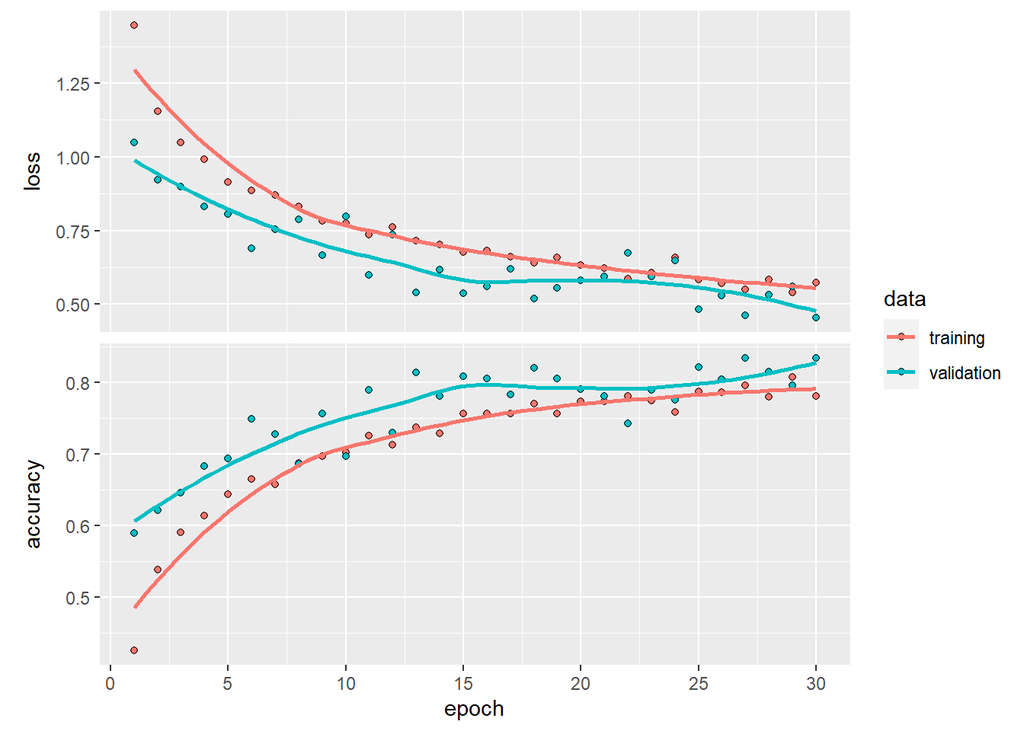

```r
Intel_model %>% compile(
  optimizer = optimizer_adam(learning_rate = 1e-3),
  loss = "categorical_crossentropy",
  metrics = c("accuracy")
)

history <- Intel_model %>% fit(
  train_generator,
  steps_per_epoch = 100,
  epochs = 30,
  validation_data = validation_generator
  )

plot(history)
```

## Valutazione del modello Il modello viene ora testato sul test set per avere un’idea del suo valore.

```r
Intel_model %>% evaluate(test_generator, steps = 50)
```

```
##      loss  accuracy
## 0.4040616 0.8550000
```

## Matrice di confusione

Qui vengono invece create 3 funzioni per avere un’idea della tipologia di errore che viene commesso e in che quantità viene commesso.

```r
#Creo la funzione valutazione che resituisce per ogni dato del test set, classe predetta e con quale percentuale.
valutazione <- function(indirizzo,gruppo){
  test1 <- list.files(path = indirizzo)
  img_path1 <- paste0("c:/data/intel/seg_test/",gruppo,"/",test1)
  probabilità <- matrix(nrow = length(test1),ncol = 6)
  classe_predetta <- matrix(nrow = length(test1),ncol = 2)
  for (i in 1:nrow(probabilità)) {
    img_test1 <- image_load(img_path1[i], target_size = c(150, 150))
    img_tensor_test1 <- image_to_array(img_test1)
    img_tensor_test1 <- array_reshape(img_tensor_test1, c(1, 150, 150, 3))
    img_tensor_test1<- img_tensor_test1/255
    prediction1 <-predict(Intel_model,img_tensor_test1)
    probabilità[i,] <- prediction1
  }
  for (i in 1:nrow(probabilità)) {
    classe_predetta[i,1] <- which.max(probabilità[i,])
    classe_predetta[i,2] <- max(probabilità[i,])
  }
  return(classe_predetta)
}
#Creo la funzione prop_class_corretta che restituisce con quale percentuale una classe venga classificata correttamente.
prop_class_corretta <- function(risultati,classe_corretta){
  count <- 0
  for (i in 1:nrow(risultati)){
    if(risultati[i,1]==classe_corretta){
      count <- count+1
      percentuale_corretti <- count/nrow(risultati)
    }
  }
  return(percentuale_corretti)
}
risultati_buildings <- valutazione(indirizzo="c:/data/intel/seg_test/buildings",gruppo="buildings")
percentuale_corretti_buildings <- prop_class_corretta(risultati_buildings,1)
risultati_forest <- valutazione(indirizzo="c:/data/intel/seg_test/forest",gruppo="forest")
percentuale_corretti_forest <- prop_class_corretta(risultati_forest,2)
risultati_glacier <- valutazione(indirizzo="c:/data/intel/seg_test/glacier",gruppo="glacier")
percentuale_corretti_glacier <- prop_class_corretta(risultati_glacier,3)
risultati_mountain <- valutazione(indirizzo="c:/data/intel/seg_test/mountain",gruppo="mountain")
percentuale_corretti_mountain <- prop_class_corretta(risultati_mountain,4)
risultati_sea <- valutazione(indirizzo="c:/data/intel/seg_test/sea",gruppo="sea")
percentuale_corretti_sea <- prop_class_corretta(risultati_sea,5)
risultati_street <- valutazione(indirizzo="c:/data/intel/seg_test/street",gruppo="street")
percentuale_corretti_street <- prop_class_corretta(risultati_street,6)
```

Con gli output delle funzioni precedenti creiamo la matrice di confusione che ci permette di analizzare da dove arrivino gli errori, e le considerazioni che possono derivare da essi.

```r
#Matrice_di_confusione è la funzione che crea la matrice di confusione
Matrice_di_confusione <- function(Matrice_Di_Confusione,risultati,z){
  for (i in 1:6) {
    count <- 0
    for(j in 1:nrow(risultati))
    if(risultati[j,1]==i){
      count<-count+1
      Matrice_Di_Confusione[i,z] <- count
    }
  }
  for(i in 1:6){
    if(is.na(Matrice_Di_Confusione[i,z])){
      Matrice_Di_Confusione[i,z]<-0
    }
  }
  Matrice_Di_Confusione
}


Matrice_Di_Confusione <- matrix(nrow = 6,ncol = 6)
Matrice_Di_Confusione <- Matrice_di_confusione(Matrice_Di_Confusione,risultati_buildings,1)
Matrice_Di_Confusione <- Matrice_di_confusione(Matrice_Di_Confusione,risultati_forest,2)
Matrice_Di_Confusione <- Matrice_di_confusione(Matrice_Di_Confusione,risultati_glacier,3)
Matrice_Di_Confusione <- Matrice_di_confusione(Matrice_Di_Confusione,risultati_mountain,4)
Matrice_Di_Confusione <- Matrice_di_confusione(Matrice_Di_Confusione,risultati_sea,5)
Matrice_Di_Confusione <- Matrice_di_confusione(Matrice_Di_Confusione,risultati_street,6)
colnames(Matrice_Di_Confusione) <- c("buildings", "forest", "glacier", "mountain", "sea", "street")
rownames(Matrice_Di_Confusione) <- c("buildings", "forest", "glacier", "mountain", "sea", "street")
Matrice_Di_Confusione
```

```
##           buildings forest glacier mountain sea street
## buildings       333      0       0        0   4     22
## forest            5    464       1        3   4     18
## glacier           4      2     472       94  44      2
## mountain         12      4      39      387  19      3
## sea               8      2      23       40 432      2
## street           75      2       0        0   6    454
```

Notiamo subito dalla matrice di confusione come la maggior parte degli errori provengano dalla classificazione di mountain, glacier e sea.